# 30maymultinomial

# Prediction

### Predict the log odds

```r
summary(log_baseline)
```

```
##
## Call:
## vglm(formula = fetalhealth2 ~ baseline, family = multinomial,
##     data = datafh)
##
## Coefficients:
##                 Estimate Std. Error z value Pr(>|z|)
## (Intercept):1  -1.795411   1.122032  -1.600    0.110
## (Intercept):2 -17.752466   1.143898 -15.519   <2e-16 ***
## baseline:1     -0.003380   0.008497  -0.398    0.691
## baseline:2      0.117033   0.008171  14.323   <2e-16 ***
## ---
## Signif. codes:  0 '***' 0.001 '**' 0.01 '*' 0.05 '.' 0.1 ' ' 1
##
## Names of linear predictors: log(mu[,1]/mu[,3]), log(mu[,2]/mu[,3])
##
## Residual deviance: 2604.138 on 4248 degrees of freedom
##
## Log-likelihood: -1302.069 on 4248 degrees of freedom
##
## Number of Fisher scoring iterations: 5
##
## Warning: Hauck-Donner effect detected in the following estimate(s):
## '(Intercept):2'
##
##
## Reference group is level  3  of the response
```

The predicted log odds for the first 6 observations:

1. the predicted log odds for pathological vs normal in column 1
2. the predicted log odds for suspect vs normal in column 2

   ```r
   head(predict.vgam(log_baseline, type = 'link'))
   ```

   ```
   ##   log(mu[,1]/mu[,3]) log(mu[,2]/mu[,3])
   ## 1          -2.201066          -3.708501
   ## 2          -2.241631          -2.304105
   ## 3          -2.245012          -2.187071
   ## 4          -2.248392          -2.070038
   ## 5          -2.241631          -2.304105
   ## 6          -2.248392          -2.070038
   ```

You can verify these prediction manually. For example the calculations for:

1. the 1st observation log odds
2. the 3rd observation log odds

   ```r
   head(datafh)[1:3,]
   ```

   | fetalhealth | baseline | abnvar | uterinecontractions | fetalmovement | fetalhealth2 | fetalhealth2_relev |
   | --- | --- | --- | --- | --- | --- | --- |
   | 2 | 120 | 73 | 0.000 | 0 | suspect | suspect |
   | 1 | 132 | 17 | 0.006 | 0 | normal | normal |
   | 1 | 133 | 16 | 0.008 | 0 | normal | normal |

The values for the

- the 1st observation are baseline = 120
- the 3rd observation are baseline = 133

  ```r
  # ptn 1: baseline = 120
  # logit fetalhealth2=pathological = [1]  vs fetalhealth2=normal =[3]
  #-1.795411  +  -0.003380 *120
  -1.795411   +  -0.003380 *120
  ```

  ```
  ## [1] -2.201011
  ```

```r
# logit fetalhealth2=suspect = [2]  vs fetalhealth2=normal =[3]
# -17.752466 +0.117033*120
-17.752466   +0.117033*120
```

```
## [1] -3.708506
```

```r
# ptn 3: baseline = 133
# logit fetalhealth2=pathological = [1]  vs fetalhealth2=normal =[3]
# -1.795411  +  -0.003380 *133
 -1.795411   +  -0.003380 *133
```

```
## [1] -2.244951
```

```r
# logit fetalhealth2=suspect = [2]  vs fetalhealth2=normal =[3]
# -17.752466 +0.117033*133
-17.752466   +0.117033*133
```

```
## [1] -2.187077
```

### Predict the probability

The predicted probability for the first 6 observation

```r
head(predict.vgam(log_baseline, type = 'response'))
```

```
##   pathological    suspect    normal
## 1   0.09750282 0.02159466 0.8809025
## 2   0.08812045 0.08278371 0.8290958
## 3   0.08695519 0.09214220 0.8209026
## 4   0.08570640 0.10244039 0.8118532
## 5   0.08812045 0.08278371 0.8290958
## 6   0.08570640 0.10244039 0.8118532
```

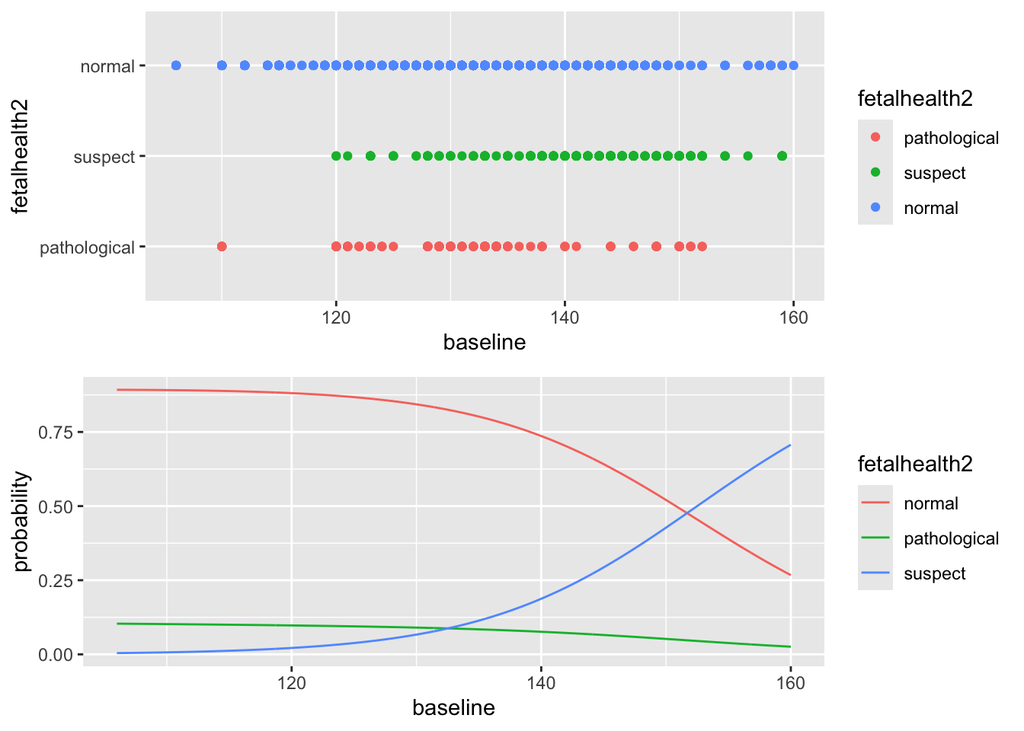

```r
# Plotting the data ---------------------------
data_plot <- datafh %>%
  ggplot(aes(x = baseline, y = fetalhealth2, color = fetalhealth2))+
  geom_point()+
  coord_cartesian(xlim = c(min(datafh$baseline), max(datafh$baseline)))


# Predicting the probabilities ---------------
new_data <- data.frame(baseline = seq(min(datafh$baseline), max(datafh$baseline), by = 0.1))
prediction <- as.data.frame(predict(log_baseline, new_data, type = 'response'))
new_data <- cbind(new_data, prediction)

# Plotting the probabilities -----------------
prob_plot <- new_data %>%
  pivot_longer(-baseline, names_to = "fetalhealth2", values_to = "probability") %>%
  ggplot(aes(x = baseline, y = probability, color = fetalhealth2))+
  geom_line()

# Merging the two plots -----------------------
ggarrange(data_plot, prob_plot, nrow = 2)
```

Manual calculation for probability. Let us take the first observation where,

1. log odds for group pathological: -2.201066
2. log odds for group suspect: -3.708501

```r
# probability being in the reference group (fetalhealth2 == normal = [3])
# 1/(1 + exp( -2.201066) + exp(-3.708501)
1/(1 + exp( -2.201066  ) + exp(-3.708501))
```

```
## [1] 0.8809025
```

```r
# probability being in the suspect group (fetalhealth2 == suspect = [2])
# exp(-3.708501)/(1 + exp(-3.708501) + exp(-2.201066))
exp(-3.708501)/(1 + exp(-3.708501) + exp(-2.201066))
```

```
## [1] 0.02159466
```

```r
# probability being in the pathological group (fetalhealth2 == pathological = [1])
# exp(-2.201066))/(1 + exp(-3.708501)) + exp(-2.201066)))
exp(-2.201066)/(1 + exp(-3.708501) + exp(-2.201066))
```

```
## [1] 0.09750279
```